# 1. IMPORTING LIBRARIES

# 7.2 Logistic Regression

```python
C=[0.01, 0.1, 1, 5,10, 20, 30]
penalty=['l2','l1']
hyperparameters=dict(C=C, penalty=penalty)
lr=LogisticRegression()
clf = GridSearchCV(lr, hyperparameters, cv=3, verbose=0)
best_model=clf.fit(x_train,y_train)
# View best hyperparameters
print('Best Penalty:', best_model.best_estimator_.get_params()['penalty'])
print('Best C:', best_model.best_estimator_.get_params()['C'])
best_penalty=best_model.best_estimator_.get_params()['penalty']
best_c=best_model.best_estimator_.get_params()['C']
```

```
Best Penalty: l2
Best C: 0.1
```

# Fitting with the best Parameters

```
Accuracy:  0.9000737463126843

Confusion Matrix
[[1215  147]
 [ 124 1226]]
```

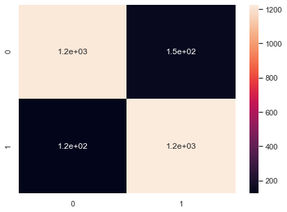

```
classification report for test data:
              precision    recall  f1-score   support

     class 0       0.91      0.89      0.90      1362
     class 1       0.89      0.91      0.90      1350

    accuracy                           0.90      2712
   macro avg       0.90      0.90      0.90      2712
weighted avg       0.90      0.90      0.90      2712
```

```python
lr=LogisticRegression(C=best_c,penalty=best_penalty)
lr.fit(x_train,y_train)

predicted_labels = lr.predict(x_test)
lr.score(x_test, y_test)
print("Accuracy: ",lr.score(x_test, y_test))
print(" "*100)
print("Confusion Matrix")
cm=metrics.confusion_matrix(y_test, predicted_labels)
print(cm)
df_cm = pd.DataFrame(cm)
plt.figure(figsize = (7,5))
sns.heatmap(df_cm, annot=True)
plt.show()
target_names = ['class 0', 'class 1']
print(" "*100)
print("classification report for test data:")
print(classification_report(y_test, predicted_labels, target_names=target_names))
```

The confusion matrix

True Negatives (TN): we correctly predicted that they did not take Personal Loan 1215

False Positives (FP): we incorrectly predicted that they took Personal Loan (a "Type I error") 147 Falsely predict positive Type I error

False Negatives (FN): we incorrectly predicted that they did not take Personal Loan (a "Type II error") 124 Falsely predict negative Type II error

True Positives (TP): we correctly predicted that they do took Personal Loan 1226

# 7.3 Naive Bayes

```
Accuracy:  0.8226401179941003

Number of mislabeled points out of a total 2712 points : 481

Confusion Matrix
[[1199  163]
 [ 318 1032]]
```

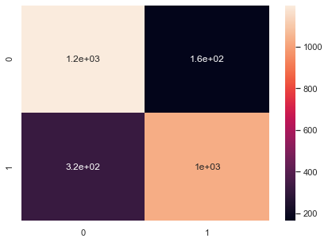

```
classification report for test data:
              precision    recall  f1-score   support

     class 0       0.79      0.88      0.83      1362
     class 1       0.86      0.76      0.81      1350

    accuracy                           0.82      2712
   macro avg       0.83      0.82      0.82      2712
weighted avg       0.83      0.82      0.82      2712
```

```python
gnb = GaussianNB()
gnb.fit(x_train,y_train)
predicted_labels=gnb.predict(x_test)
print("Accuracy: ",gnb.score(x_test, y_test))
print(" "*100)
print("Number of mislabeled points out of a total %d points : %d"
       % (x_test.shape[0], (y_test != predicted_labels).sum()))
print(" "*100)
print("Confusion Matrix")
cm=metrics.confusion_matrix(y_test, predicted_labels)
print(cm)
df_cm = pd.DataFrame(cm)
plt.figure(figsize = (7,5))
sns.heatmap(df_cm, annot=True)
plt.show()
target_names = ['class 0', 'class 1']
print(" "*100)
print("classification report for test data:")
print(classification_report(y_test, predicted_labels, target_names=target_names))
```

The confusion matrix

True Negatives (TN): we correctly predicted that they did not take Personal Loan 1199

False Positives (FP): we incorrectly predicted that they took Personal Loan (a "Type I error") 163 Falsely predict positive Type I error

False Negatives (FN): we incorrectly predicted that they did not take Personal Loan (a "Type II error") 318 Falsely predict negative Type II error

True Positives (TP): we correctly predicted that they do took Personal Loan 1032

# 7.4 Support Vector Machine

```python
# defining parameter range
param_grid = {'C': [0.01, 0.1, 1, 10],
              'gamma': [1, 0.1, 0.01, 0.001],
              'kernel': ['rbf','linear']}

grid = GridSearchCV(SVC(), param_grid, refit = True, verbose = 3)

# fitting the model for grid search
best_model=grid.fit(x_train, y_train)

# View best hyperparameters
print('Best gamma:', best_model.best_estimator_.get_params()['gamma'])
print('Best C:', best_model.best_estimator_.get_params()['C'])
print('Best kernel:', best_model.best_estimator_.get_params()['kernel'])
best_gamma=best_model.best_estimator_.get_params()['gamma']
best_c=best_model.best_estimator_.get_params()['C']
best_kernel=best_model.best_estimator_.get_params()['kernel']
print("Best Score:", best_model.best_score_)
```

[output not shown]

[output not shown]

[output not shown]

[output not shown]

[output not shown]

[output not shown]

[output not shown]

[output cut: 264 more lines]

```
[CV] ....... C=10, gamma=0.001, kernel=rbf, score=0.899, total=   0.5s
[CV] C=10, gamma=0.001, kernel=linear ................................
[CV] .... C=10, gamma=0.001, kernel=linear, score=0.899, total=   0.5s
[CV] C=10, gamma=0.001, kernel=linear ................................
[CV] .... C=10, gamma=0.001, kernel=linear, score=0.895, total=   0.4s
[CV] C=10, gamma=0.001, kernel=linear ................................
[CV] .... C=10, gamma=0.001, kernel=linear, score=0.897, total=   0.4s
[CV] C=10, gamma=0.001, kernel=linear ................................
[CV] .... C=10, gamma=0.001, kernel=linear, score=0.891, total=   0.4s
[CV] C=10, gamma=0.001, kernel=linear ................................
[CV] .... C=10, gamma=0.001, kernel=linear, score=0.898, total=   0.5s
Best gamma: 1
Best C: 10
Best kernel: rbf
Best Score: 0.9841984651793018
```

[output not shown]